# P259: Model selection

Dendritic cells (pDC)

Kim Dill-McFarland, kadm@uw.edu

version May 18, 2021

# Background

The purpose of this workflow is to identify differentially expressed genes in pDC. Several models are compared in order to determine the best way to extract the effects of Anti-IL5 therapy and eosinophil (EOS) supernatant over the much larger human rhinovirus (RV) signal.

# Setup

Load packages

```r
# Data manipulation and figures
library(tidyverse)
    # Multi-panel figures for ggplot
    library(cowplot)
    # Add p-values to plots
    library(ggpubr)
#Venn diagrams
library(venn)
#Linear models
library(limma)
#Define ggplot colors
group.cols <- c("none:none"="#dadaeb",
               "none:AntiIL5"="#9e9ac8",
               "none:EOS.supp"="#54278f",
               "HRV:none"="#c7e9c0",
               "HRV:AntiIL5"="#74c476",
               "HRV:EOS.supp"="#006d2c",
               "flu:none"="#fdae6b",
               "flu:AntiIL5"="#e6550d")
samp.cols <- c("AC1"="#969696",
               "AC2"="#a6cee3",
               "AC3"="#1f78b4",
               "AC4"="#b2df8a",
               "AC5"="#33a02c",
               "AT1"="#fb9a99",
               "AT2"="#e31a1c",
               "AT3"="#fdbf6f",
               "AT4"="#ff7f00",
               "donor1"="#cab2d6",
               "donor2"="#6a3d9a",
               "donor3"="#ffff99",
               "donor4"="#b15928")

# Print tty table to knit file
library(knitr)
library(kableExtra)
```

Set seed

```r
set.seed(4389)
```

Scripts and functions

```r
#To extract and format p-value from lmFit
source("https://raw.githubusercontent.com/kdillmcfarland/R_bioinformatic_scripts/master/limma.extract.pval.R")
#opposite of %in%
`%notin%` <- Negate(`%in%`)
```

# Load data

Load normalized edgeR data objects. RNA-seq data was cleaned and normalized in data cleaning. This included filtering for median CV coverage, mapped duplicate reads, total aligned counts, PCA outliers, and rare genes.

```r
load("data_clean/P259_pDC_clean.RData")
```

This includes in the following pDC samples.

| experiment | asthma | IL5 | virus | n |
| --- | --- | --- | --- | --- |
| P259_1 | healthy | none | none | 4 |
|  |  | none | HRV | 4 |
|  |  | EOS.supp | none | 3 |
|  |  | EOS.supp | HRV | 4 |
| P259_2 | asthma | none | none | 3 |
|  |  | none | HRV | 6 |
|  |  | AntiIL5 | none | 4 |
|  |  | AntiIL5 | HRV | 8 |

# Variables of interest

**Main effects**

- `donorID`: character for each donor (N = 11)
- `IL5`: factor of patient AntiIL5 therapy or sample EOS supernatant treatment (none, AntiIL5, EOS.supp)
- `virus`: factor of viral conditions (none, HRV)

**Fixed effects**

- `Sex`: NA, Male, Female
- `Age`: age, years (11 - 32)
  - Neither available for 2 of 4 donors in P259.1

## Explore fixed effects and possible confounding variables

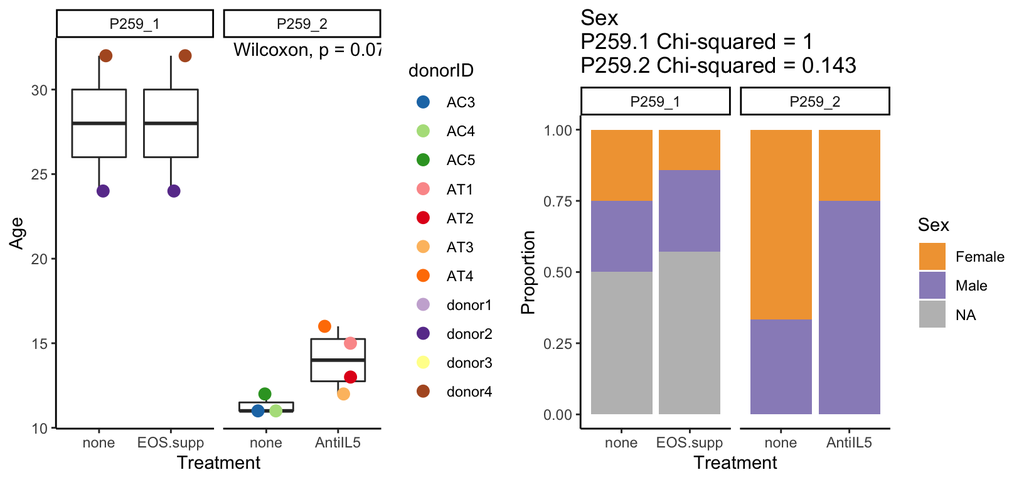

Age and sex appear to be different between treatment groups but are technically not significantly different, likely as the result of the small sample size. Due to this, the small sample size, and missing data in P259.1, sex and age will not be used as co-variates.

# PCA

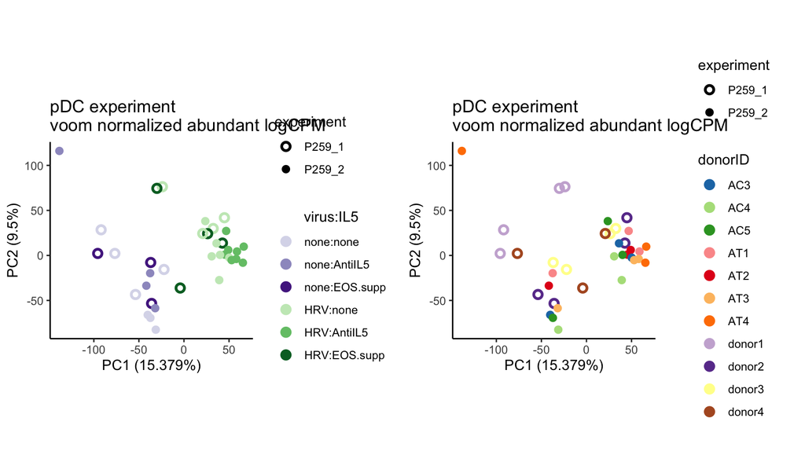

# P259.1 model comparison

## Run models

### Interaction model

`gene expression ~ EOS.supp * virus + (1|donor)`

```r
# Define model
model_1.interact <- model.matrix(~ IL5*virus,
                          data=dat.pDC.voom_1$targets)
    colnames(model_1.interact) <- c("(Intercept)", "EOS.supp",
                            "HRV", "EOS.supp:HRV")
#Block by donor
consensus.corr <- duplicateCorrelation(
  dat.pDC.voom_1$E,
  model_1.interact,
  block=dat.pDC.voom_1$targets$donorID)$consensus.correlation

consensus.corr
```

```
## [1] 0.265985
```

```r
# Fit model to transformed count data. Calculate eBayes
efitQW_1.interact <- eBayes(
                lmFit(dat.pDC.voom_1$E,
                      model_1.interact,
                      block=dat.pDC.voom_1$targets$donorID,
                      correlation=consensus.corr))
```

Summary

| Variable | Total genes at FDR <0.05 | Total genes at FDR <0.1 | Total genes at FDR <0.2 | Total genes at FDR <0.3 | Total genes at FDR <0.4 | Total genes at FDR <0.5 |
| --- | --- | --- | --- | --- | --- | --- |
| EOS.supp | 2 | 2 | 5 | 10 | 10 | 10 |
| HRV | 1011 | 1697 | 2937 | 4012 | 5075 | 6290 |
| EOS.supp:HRV | 0 | 0 | 0 | 3 | 3 | 3 |
| total (nonredundant) | 1011 | 1697 | 2939 | 4013 | 5076 | 6291 |

### Contrasts model

`gene expression ~ EOS.supp:virus + (1|donor)`

```r
# Define model
dat.pDC.voom_1$targets <- dat.pDC.voom_1$targets %>%
  mutate(contrast=paste(IL5, virus, sep="_")) %>%
  mutate(contrast=factor(contrast,
                         levels = c("none_none","none_HRV",
                                 "EOS.supp_none","EOS.supp_HRV")))

model_1.contrast<- model.matrix(~ 0 + contrast,
                          data=dat.pDC.voom_1$targets)
    colnames(model_1.contrast) <- c(
                                 "none_none","none_HRV",
                                 "EOS.supp_none","EOS.supp_HRV")
#Block by donor
consensus.corr <- duplicateCorrelation(
  dat.pDC.voom_1$E,
  model_1.contrast,
  block=dat.pDC.voom_1$targets$donorID)$consensus.correlation

consensus.corr
```

```
## [1] 0.265985
```

```r
#Fit model
fitQW_1.contrast <- lmFit(dat.pDC.voom_1$E,
                      model_1.contrast,
                      block=dat.pDC.voom_1$targets$donorID,
                      correlation=consensus.corr)
#Get contrasts
contrast.matrix <- makeContrasts(
  none_HRV-none_none,
  EOS.supp_HRV-EOS.supp_none,
  EOS.supp_none-none_none,
  EOS.supp_HRV-none_HRV,
  levels=model_1.contrast)

efitQW_1.contrast <- eBayes(contrasts.fit(fitQW_1.contrast,
                                  contrast.matrix))
```

Summary

| Variable | Total genes at FDR <0.05 | Total genes at FDR <0.1 | Total genes at FDR <0.2 | Total genes at FDR <0.3 | Total genes at FDR <0.4 | Total genes at FDR <0.5 |
| --- | --- | --- | --- | --- | --- | --- |
| none_HRV - none_none | 1011 | 1697 | 2937 | 4012 | 5075 | 6290 |
| EOS.supp_HRV - EOS.supp_none | 79 | 394 | 1050 | 1817 | 2739 | 3838 |
| EOS.supp_none - none_none | 2 | 2 | 5 | 10 | 10 | 10 |
| EOS.supp_HRV - none_HRV | 0 | 0 | 0 | 0 | 0 | 0 |
| total (nonredundant) | 1027 | 1781 | 3206 | 4522 | 5875 | 7427 |

#### Contrast selected genes

Genes of interest are those that change with virus (*e.g.* significant for virus in untreated and/or treated samples) AND with EOS supernatant in media OR HRV.

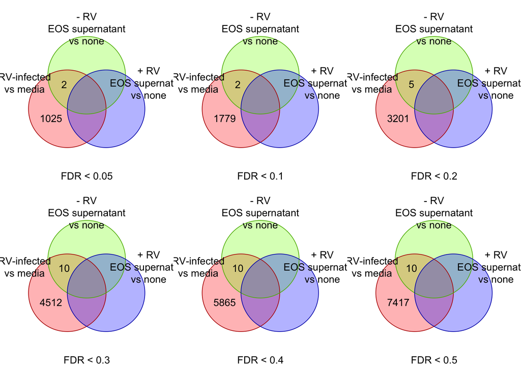

### Delta model

`RV - media gene expression ~ EOS.supp + (1|donor)`

Calculate HRV - media counts.

Fit model

```r
# Define model
model_1.delta <- model.matrix(~ IL5,
                          data=dat.pDC.voom_1.delta.tgts)
    colnames(model_1.delta) <- c("(Intercept)","EOS.supp")

#Block by donor
consensus.corr <- duplicateCorrelation(
  dat.pDC.voom_1.delta.E,
  model_1.delta,
  block=dat.pDC.voom_1.delta.tgts$donorID)$consensus.correlation
consensus.corr
```

```
## [1] 0.1272602
```

```r
# Fit model to transformed count data. Calculate eBayes
efitQW_1.delta <- eBayes(
                lmFit(dat.pDC.voom_1.delta.E,
                      model_1.delta,
                      block=dat.pDC.voom_1.delta.tgts$donorID,
                      correlation=consensus.corr))
```

Summary

| Variable | Total genes at FDR <0.05 | Total genes at FDR <0.1 | Total genes at FDR <0.2 | Total genes at FDR <0.3 | Total genes at FDR <0.4 | Total genes at FDR <0.5 |
| --- | --- | --- | --- | --- | --- | --- |
| EOS.supp | 0 | 0 | 0 | 1 | 11 | 12 |
| total (nonredundant) | 0 | 0 | 0 | 1 | 11 | 12 |

## Compare models

Total genes significant in one or more models at FDR < 0.1

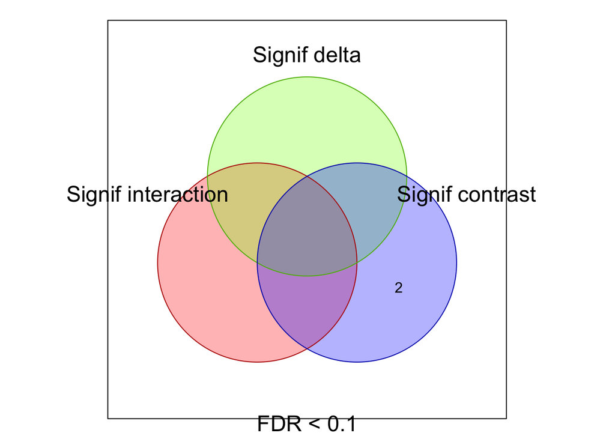

## Save results

```r
dir.create("results/gene_level/P259.1_model.selection/",
           showWarnings = FALSE, recursive = TRUE)

save(pval_1.interact, pval_1.contrast, pval_1.delta,
     file="results/gene_level/P259.1_model.selection/P259.1_gene_pval.RData")

#gene lists
save(venn.list, file="results/gene_level/P259.1_model.selection/P259.1_gene_lists.RData")

#pval csv
pval_1.interact %>%
  mutate(model = "interaction") %>%
  bind_rows(mutate(pval_1.contrast,
                   model="contrasts")) %>%
  bind_rows(mutate(pval_1.delta,
                   model="delta")) %>%
  #Add HGNC symbol
  left_join(dat.pDC.voom_1$genes) %>%
  write_csv(path = "results/gene_level/P259.1_gene_pval.csv")
```

# P259.2 model comparison

## Run models

### Interaction model

`gene expression ~ AntiIL5 * virus + (1|donor)`

```r
# Define model
model_2.interact <- model.matrix(~ IL5*virus,
                          data=dat.pDC.voom_2$targets)
    colnames(model_2.interact) <- c("(Intercept)", "AntiIL5",
                            "HRV", "AntiIL5:HRV")
#Block by donor
consensus.corr <- duplicateCorrelation(
  dat.pDC.voom_2$E,
  model_2.interact,
  block=dat.pDC.voom_2$targets$donorID)$consensus.correlation

consensus.corr
```

```
## [1] 0.1119666
```

```r
# Fit model to transformed count data. Calculate eBayes
efitQW_2.interact <- eBayes(
                lmFit(dat.pDC.voom_2$E,
                      model_2.interact,
                      block=dat.pDC.voom_2$targets$donorID,
                      correlation=consensus.corr))
```

Summary

| Variable | Total genes at FDR <0.05 | Total genes at FDR <0.1 | Total genes at FDR <0.2 | Total genes at FDR <0.3 | Total genes at FDR <0.4 | Total genes at FDR <0.5 |
| --- | --- | --- | --- | --- | --- | --- |
| AntiIL5 | 18 | 34 | 89 | 168 | 309 | 536 |
| HRV | 1031 | 1538 | 2271 | 3095 | 4062 | 5221 |
| AntiIL5:HRV | 14 | 23 | 45 | 90 | 1160 | 2321 |
| total (nonredundant) | 1042 | 1556 | 2315 | 3184 | 4816 | 6543 |

### Contrasts model

`gene expression ~ AntiIL5:virus + (1|donor)`

```r
# Define model
dat.pDC.voom_2$targets <- dat.pDC.voom_2$targets %>%
  mutate(contrast=paste(IL5,virus, sep="_")) %>%
  mutate(contrast=factor(contrast,
                         levels = c("none_none","none_HRV",
                                 "AntiIL5_none","AntiIL5_HRV")))

model_2.contrast<- model.matrix(~ 0 + contrast,
                          data=dat.pDC.voom_2$targets)
    colnames(model_2.contrast) <- c(
                                 "none_none","none_HRV",
                                 "AntiIL5_none","AntiIL5_HRV")
#Block by donor
consensus.corr <- duplicateCorrelation(
  dat.pDC.voom_2$E,
  model_2.contrast,
  block=dat.pDC.voom_2$targets$donorID)$consensus.correlation

consensus.corr
```

```
## [1] 0.1119666
```

```r
#Fit model
fitQW_2.contrast <- lmFit(dat.pDC.voom_2$E,
                      model_2.contrast,
                      block=dat.pDC.voom_2$targets$donorID,
                      correlation=consensus.corr)

#Get contrasts
contrast.matrix <- makeContrasts(
  none_HRV-none_none,
  AntiIL5_HRV-AntiIL5_none,
  AntiIL5_none-none_none,
  AntiIL5_HRV-none_HRV,
  levels=model_2.contrast)

efitQW_2.contrast <- eBayes(contrasts.fit(fitQW_2.contrast,
                                  contrast.matrix))
```

Summary

| Variable | Total genes at FDR <0.05 | Total genes at FDR <0.1 | Total genes at FDR <0.2 | Total genes at FDR <0.3 | Total genes at FDR <0.4 | Total genes at FDR <0.5 |
| --- | --- | --- | --- | --- | --- | --- |
| none_HRV - none_none | 1031 | 1538 | 2271 | 3095 | 4062 | 5221 |
| AntiIL5_HRV - AntiIL5_none | 2577 | 3673 | 5274 | 6538 | 7646 | 8667 |
| AntiIL5_none - none_none | 18 | 34 | 89 | 168 | 309 | 536 |
| AntiIL5_HRV - none_HRV | 0 | 3 | 4 | 4 | 4 | 4 |
| total (nonredundant) | 2848 | 4119 | 5948 | 7466 | 8836 | 10109 |

### Contrast selected genes

Genes of interest are those that change with virus (*e.g.* significant for virus in untreated and/or treated donors) AND are different between untreated and treated donors in media OR RV.

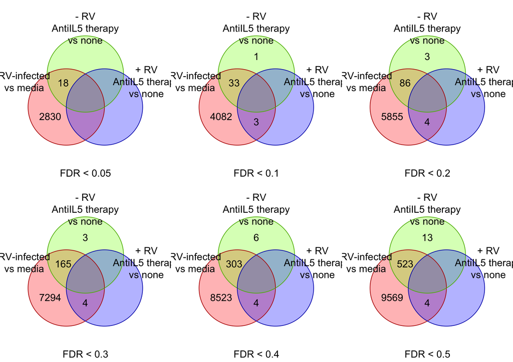

### Delta model

`RV - media gene expression ~ AntiIL5`

Calculate HRV - media counts.

Fit model

```r
# Define model
model_2.delta <- model.matrix(~ IL5,
                          data=dat.pDC.voom_2.delta.tgts)
    colnames(model_2.delta) <- c("(Intercept)","AntiIL5")

#Block by donor
consensus.corr <- duplicateCorrelation(
  dat.pDC.voom_2.delta.E,
  model_2.delta,
  block=dat.pDC.voom_2.delta.tgts$donorID)$consensus.correlation

consensus.corr
```

```
## [1] 0.6068913
```

```r
# Fit model to transformed count data. Calculate eBayes
efitQW_2.delta <- eBayes(
                lmFit(dat.pDC.voom_2.delta.E,
                      model_2.delta,
                      block=dat.pDC.voom_2.delta.tgts$donorID,
                      correlation=consensus.corr))
```

Summary

| Variable | Total genes at FDR <0.05 | Total genes at FDR <0.1 | Total genes at FDR <0.2 | Total genes at FDR <0.3 | Total genes at FDR <0.4 | Total genes at FDR <0.5 |
| --- | --- | --- | --- | --- | --- | --- |
| AntiIL5 | 1 | 7 | 9 | 17 | 29 | 55 |
| total (nonredundant) | 1 | 7 | 9 | 17 | 29 | 55 |

## Compare models

Total genes significant in one or more models at FDR < 0.1

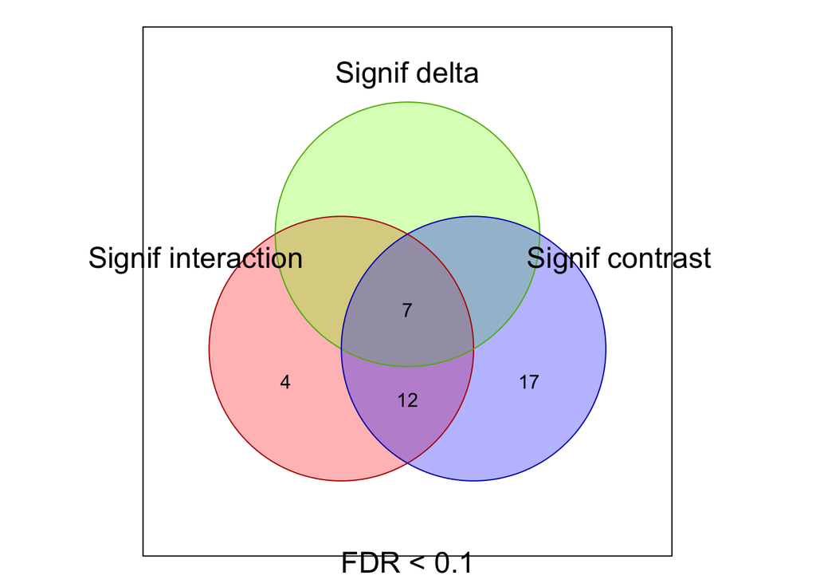

## Save results

```r
dir.create("results/gene_level/P259.2_model.selection/",
           showWarnings = FALSE, recursive = TRUE)

save(pval_2.interact, pval_2.contrast, pval_2.delta,
     file="results/gene_level/P259.2_model.selection/P259.2_gene_pval.RData")

#gene lists
save(venn.list, file="results/gene_level/P259.2_model.selection/P259.2_gene_lists.RData")

#pval csv
pval_2.interact %>%
  mutate(model = "interaction") %>%
  bind_rows(mutate(pval_2.contrast,
                   model="contrasts")) %>%
  bind_rows(mutate(pval_2.delta,
                   model="delta")) %>%
  #Add HGNC symbol
  left_join(dat.pDC.voom_2$genes) %>%
  write_csv(path = "results/gene_level/P259.2_gene_pval.csv")
```